# *Isolation Forest*

## *Characteristics of anomalies*

*Since anomalies deviate from normal, they are few in numbers (minority) and/or have attribute values that are very different from those of normal. The paper nicely puts it as few and different. These characteristics of anomalies make them more susceptible to isolation than normal points and form the guiding principle of the Isolation Forest algorithm.*

## *What is Isolation Forest?*

*Isolation Forest is an algorithm to detect outliers that returns the anomaly score of each sample using the IsolationForest algorithm which is based on the fact that anomalies are data points that are few and different. Isolation Forest is a tree-based model. In these trees, partitions are created by first randomly selecting a feature and then selecting a random split value between the minimum and maximum value of the selected feature.*

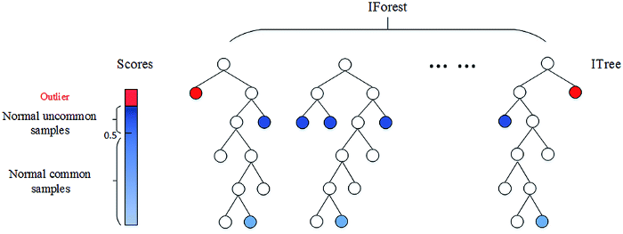

### *The issue with the usual approach*

*The usual methods are not optimized to detect anomalies, instead, they are optimized to find normal instances, because of which the result of anomaly detection either contains too many false positives or might detect too few anomalies. Many of these methods are computationally complex and hence suit low dimensional and/or small-sized data.*

*Isolation Forest algorithm addresses both of the above concerns and provides an efficient and accurate way to detect anomalies.*

### *The core principle*

*The core of the algorithm is to “isolate” anomalies by creating decision trees over random attributes. The random partitioning produces noticeable shorter paths for anomalies since*

- *fewer instances (of anomalies) result in smaller partitions*
- *distinguishable attribute values are more likely to be separated in early partitioning*

*Hence, when a forest of random trees collectively produces shorter path lengths for some particular points, then they are highly likely to be anomalies.*

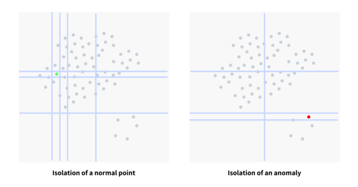

*The diagram above shows the number of splits required to isolate a normal point and an anomaly. Splits, represented through blue lines, happens at random on a random attribute and in the process building a decision tree. The number of splits determines the level at which the isolation happened and will be used to generate the anomaly score.*

*The process is repeated multiple times and we note the isolation level for each point/instance. Once the iterations are over, we generate an anomaly score for each point/instance, suggesting its likeliness to be an anomaly. The score is a function of the average level at which the point was isolated. The top m gathered on the basis of the score, are labeled as anomalies.*

#### *Step 1 — Sampling for Training*

*The very first step is sampling for training a model* *Depending on the underlying data set, a sampling proportion can be different (i.e. more noisy data -> higher sampling proportion can be preferable)*

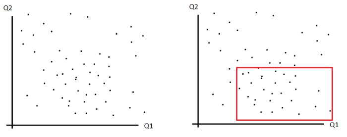

#### *Step 2 — Binary decision tree*

*The following step essentially involves making a tree for the sample we drew from step 1* *This step involves two random elements: random choice of an attribute (i.e. Q1 or Q2) / random choice of a Q1 or Q2 value between its min and max (i.e. Q1’)*

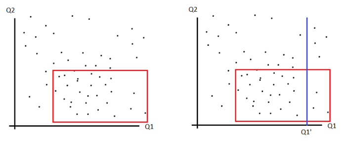

#### *Step 3 — Repeat step 2 Iteratively*

- *Do step 2 for two sub-data set based on the binary split from step 2*
- *“Fewer and different” data points are isolated quicker such as the data point at the very lower right corner*
- *In other words, it takes less path for them to be isolated*
- *Do this iteratively to create a forest, a collection of trees*

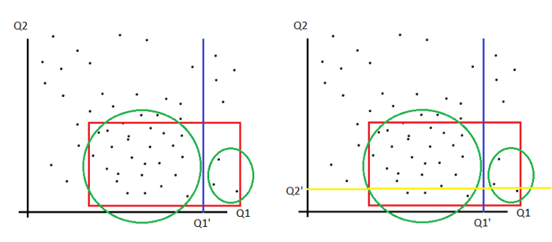

#### *Step 4 — Feeding data set and calculating anomaly score*

*Feed each data point into a trained forest model for each tree*

*Anomaly score is defined as:*

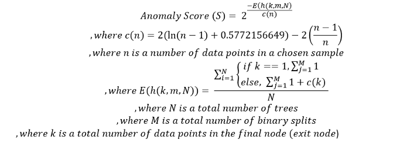

- *We calculate this anomaly score for each tree and average them out across different trees and get the final anomaly score for an entire forest for a given data point*
- *Mathematically, an outlier gets a score closer to 1.*

## *Mall Customer Anomaly Detection*

```python
import pandas as pd
import numpy as np

import matplotlib.pyplot as plt
%matplotlib inline

import seaborn as sns

plt.style.use('seaborn-pastel')

# to display the total number columns present in the dataset
pd.set_option('display.max_columns', None)
```

```python
data = pd.read_csv(r'C:\Users\PiyushSin\Desktop\datasets\Mall_Customers.csv')
data.head()
```

|  | CustomerID | Gender | Age | Annual Income (k$) | Spending Score (1-100) |
| --- | --- | --- | --- | --- | --- |
| 0 | 1 | Male | 19 | 15 | 39 |
| 1 | 2 | Male | 21 | 15 | 81 |
| 2 | 3 | Female | 20 | 16 | 6 |
| 3 | 4 | Female | 23 | 16 | 77 |
| 4 | 5 | Female | 31 | 17 | 40 |

```python
data.columns
```

```
Index(['CustomerID', 'Gender', 'Age', 'Annual Income (k$)',
       'Spending Score (1-100)'],
      dtype='object')
```

```python
data=data.drop('CustomerID',axis=1)
data=data.rename(columns={'Annual Income (k$)':'Income','Spending Score (1-100)':'Spend_Score'})
```

```python
df=pd.get_dummies(data)
df
```

|  | Age | Income | Spend_Score | Gender_Female | Gender_Male |
| --- | --- | --- | --- | --- | --- |
| 0 | 19 | 15 | 39 | 0 | 1 |
| 1 | 21 | 15 | 81 | 0 | 1 |
| 2 | 20 | 16 | 6 | 1 | 0 |
| 3 | 23 | 16 | 77 | 1 | 0 |
| 4 | 31 | 17 | 40 | 1 | 0 |
| ... | ... | ... | ... | ... | ... |
| 195 | 35 | 120 | 79 | 1 | 0 |
| 196 | 45 | 126 | 28 | 1 | 0 |
| 197 | 32 | 126 | 74 | 0 | 1 |
| 198 | 32 | 137 | 18 | 0 | 1 |
| 199 | 30 | 137 | 83 | 0 | 1 |

200 rows × 5 columns

```python
from sklearn.ensemble import IsolationForest

clf = IsolationForest(max_samples=100,random_state=42, contamination=.1)
clf.fit(df)
```

```
IsolationForest(contamination=0.1, max_samples=100, random_state=42)
```

```python
if_scores = clf.decision_function(df)
if_scores
```

[output not shown]

```python
if_anomalies=clf.predict(df)
if_anomalies
```

```
array([-1, -1, -1,  1,  1,  1,  1,  1, -1,  1, -1, -1, -1,  1,  1,  1,  1,
        1,  1, -1,  1,  1, -1,  1,  1,  1,  1,  1,  1,  1, -1,  1,  1, -1,
        1,  1,  1,  1,  1,  1,  1,  1,  1,  1,  1,  1,  1,  1,  1,  1,  1,
        1,  1,  1,  1,  1,  1,  1,  1,  1,  1,  1,  1,  1,  1,  1,  1,  1,
        1,  1,  1,  1,  1,  1,  1,  1,  1,  1,  1,  1,  1,  1,  1,  1,  1,
        1,  1,  1,  1,  1,  1,  1,  1,  1,  1,  1,  1,  1,  1,  1,  1,  1,
        1,  1,  1,  1,  1,  1,  1,  1,  1,  1,  1,  1,  1,  1,  1,  1,  1,
        1,  1,  1,  1,  1,  1,  1,  1,  1,  1,  1,  1,  1,  1,  1,  1,  1,
        1,  1,  1,  1, -1,  1,  1,  1,  1,  1,  1,  1,  1,  1,  1,  1,  1,
        1,  1,  1,  1,  1,  1,  1,  1,  1,  1,  1,  1,  1,  1,  1,  1,  1,
        1,  1,  1,  1,  1,  1,  1,  1,  1,  1,  1,  1,  1,  1,  1, -1,  1,
        1,  1,  1,  1,  1, -1, -1, -1,  1, -1, -1, -1, -1])
```

```python
if_anomalies=pd.Series(if_anomalies).replace([-1,1],[1,0])
if_anomalies
```

```
0      1
1      1
2      1
3      0
4      0
      ..
195    0
196    1
197    1
198    1
199    1
Length: 200, dtype: int64
```

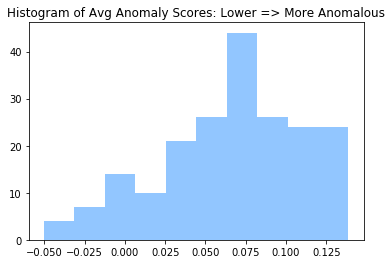

```python
plt.figure(figsize=(6,4))
plt.hist(if_scores)
plt.title('Histogram of Avg Anomaly Scores: Lower => More Anomalous')
```

```python
num = df[['Income','Spend_Score']]
if_anomalies = num[if_anomalies ==1]
```

```python
if_anomalies
```

|  | Income | Spend_Score |
| --- | --- | --- |
| 0 | 15 | 39 |
| 1 | 15 | 81 |
| 2 | 16 | 6 |
| 8 | 19 | 3 |
| 10 | 19 | 14 |
| 11 | 19 | 99 |
| 12 | 20 | 15 |
| 19 | 23 | 98 |
| 22 | 25 | 5 |
| 30 | 30 | 4 |
| 33 | 33 | 92 |
| 140 | 75 | 5 |
| 185 | 99 | 97 |
| 192 | 113 | 8 |
| 193 | 113 | 91 |
| 194 | 120 | 16 |
| 196 | 126 | 28 |
| 197 | 126 | 74 |
| 198 | 137 | 18 |
| 199 | 137 | 83 |

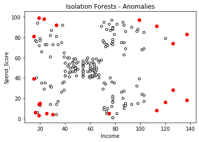

```python
plt.scatter(df.iloc[:,1],df.iloc[:,2],c='white',s=20,edgecolor='k')
plt.scatter(if_anomalies.iloc[:,0],if_anomalies.iloc[:,1],c='red')
plt.xlabel('Income')
plt.ylabel('Spend_Score')
plt.title('Isolation Forests - Anomalies')
```

_The isolation forest algorithm thrives on sub-sampled data and does not need to build the tree from the entire data set; it works well with sub-sampled data. While constructing the tree, we need not build tree taller than max*height (very cheap to compute), making it low on memory footprint. Since the algorithm does not depend on computationally expensive operations like distance or density calculation, it executes really fast. The training stage has a linear time complexity with a low constant and hence could be used in a real-time online system.*

*Isolation forest works very well even with a small data set to detect outliers*

### *Isolation Forest Pros*

*There is no need of scaling the values in the feature space.* *NON-PARAMETRIC: It is an effective method when value distributions can not be assumed.* *It has few parameters, this makes this method fairly robust and easy to optimize.*

### *Isolation Forest Cons*

*Visualizing results is complicated.* *If not correctly optimized, training time can be very long and computationally expensive.*